# Bio 724: Class Session 04, In-class Problems

## Libraries

```r
library(tidyverse)
library(patchwork)
```

## Data

```r
library(palmerpenguins)
```

## Familiarize yourself with the data

- Read about the data in the Palmer Penguins package here:

https://allisonhorst.github.io/palmerpenguins/

- Check out the structure of the `penguins` data frame:

```r
str(penguins)
```

```
tibble [344 × 8] (S3: tbl_df/tbl/data.frame)
 $ species          : Factor w/ 3 levels "Adelie","Chinstrap",..: 1 1 1 1 1 1 1 1 1 1 ...
 $ island           : Factor w/ 3 levels "Biscoe","Dream",..: 3 3 3 3 3 3 3 3 3 3 ...
 $ bill_length_mm   : num [1:344] 39.1 39.5 40.3 NA 36.7 39.3 38.9 39.2 34.1 42 ...
 $ bill_depth_mm    : num [1:344] 18.7 17.4 18 NA 19.3 20.6 17.8 19.6 18.1 20.2 ...
 $ flipper_length_mm: int [1:344] 181 186 195 NA 193 190 181 195 193 190 ...
 $ body_mass_g      : int [1:344] 3750 3800 3250 NA 3450 3650 3625 4675 3475 4250 ...
 $ sex              : Factor w/ 2 levels "female","male": 2 1 1 NA 1 2 1 2 NA NA ...
 $ year             : int [1:344] 2007 2007 2007 2007 2007 2007 2007 2007 2007 2007 ...
```

## Preface

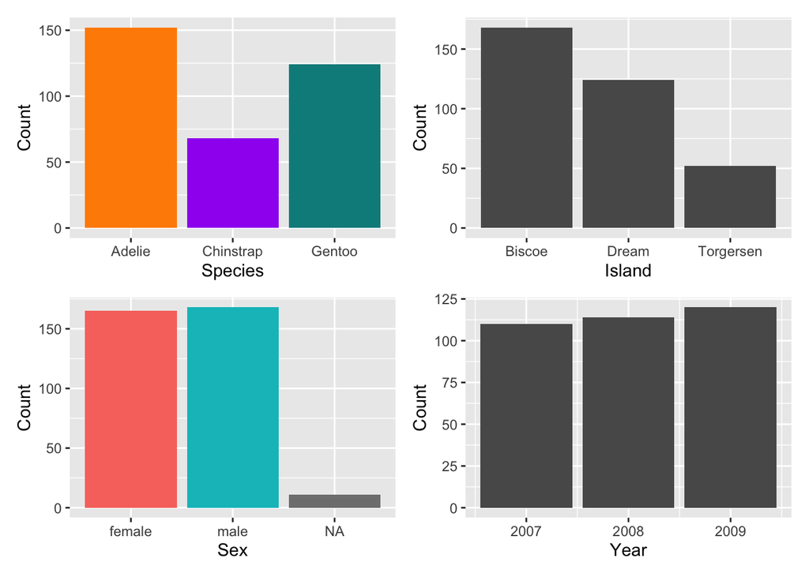

```r
# use the same fill colors as on the palmer penguins website
penguin_colors <- c("darkorange","purple","cyan4")

by_species <-
  ggplot(penguins) +
  geom_bar(aes(x = species, fill = species)) +
  scale_fill_manual(values = penguin_colors) +
  labs(x = "Species", y = "Count") +
  guides(fill = "none")  # turn off fill legend because it's redundant with x-axis

by_island <-
  ggplot(penguins, aes(x = island)) +
  geom_bar() +
  labs(x = "Island", y = "Count")

by_sex <-
  ggplot(penguins, aes(x = sex, fill = sex)) +
  geom_bar() +
  labs(x = "Sex", y = "Count") +
  guides(fill = "none")

by_year <-
  ggplot(penguins, aes(x = year)) +
  geom_bar() +
  labs(x = "Year", y = "Count")

# lay out the subplots using the patchwork package
((by_species | by_island) /
 (by_sex     | by_year))
```

## Problem 01

### Part a

**Modify the code below** to produce a stacked bar chart that shows the breakdown of sample counts by species on each island as shown below.

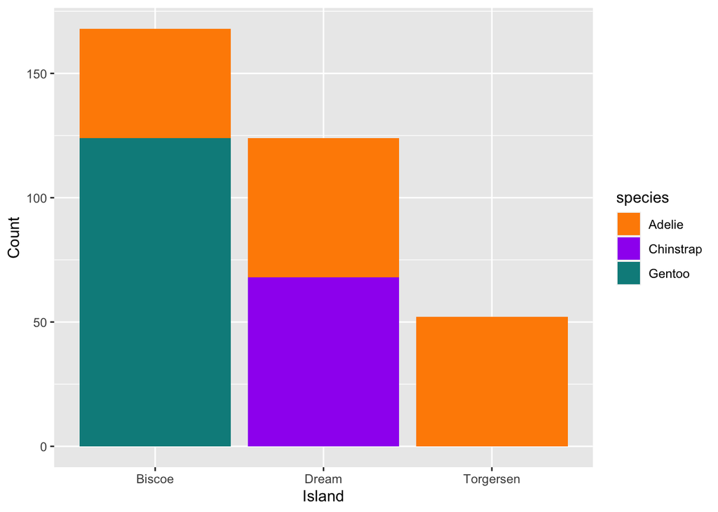

```r
ggplot(penguins, aes(x = island)) +
  geom_bar() +
  labs(x = "Island", y = "Count")
```

## Part b

What information does the combined plot convey that can not be gleaned from the seperate plots for these variables given above?

## Problem 02

The following plot show a breakdown of samples by species and sex:

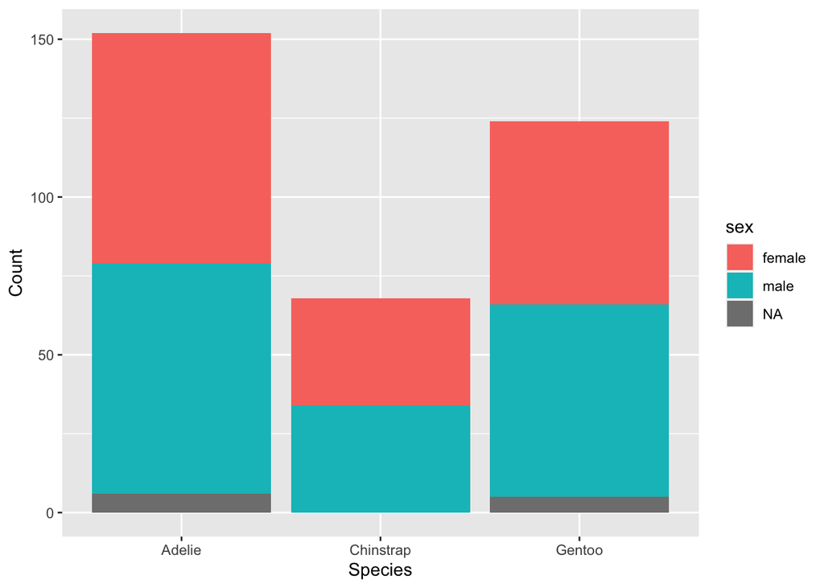

```r
penguins |>
  ggplot(aes(x=species, fill=sex)) +
  geom_bar() +
  labs(x = "Species", y = "Count")
```

### Part a

**Modify the code above** to filter out any samples with missing values of sex (`NA`) and generate the plot below with flipped coordinates:

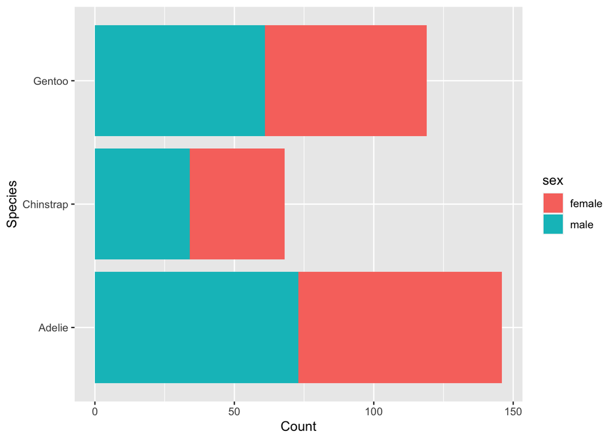

### Part b

What did we learn about the species and sex variables that we might not have already known from the single variable plots above?

## Problem 03

Faceting in ggplot is akin to `group_by()` in `dplyr`. It allows us to generate visualizations by grouping on variables of interest. The example below illustrate how to use `facet_grid` to group on the sex variable in the data set.

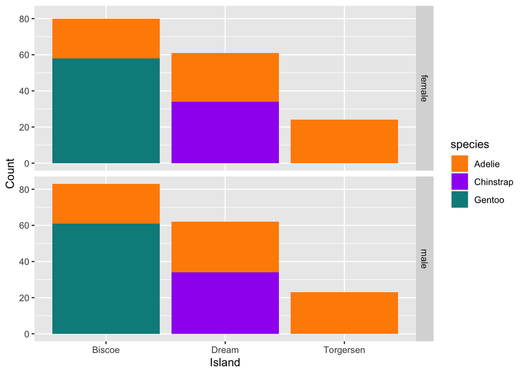

```r
penguins |>
  filter(!is.na(sex)) |>
  ggplot(aes(x = island, fill=species)) +
    geom_bar() +
    scale_fill_manual(values = penguin_colors) +
    facet_grid(row=vars(sex)) +
    labs(x = "Island", y = "Count")
```

### Part a

**Modify the code above** to generate the following figure that facets on both the `sex` and `year` variables.

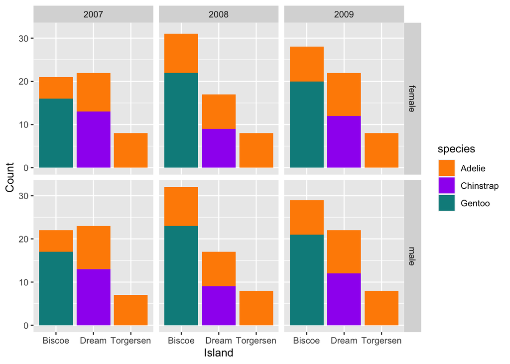

### Part b

What did we learn about the the four variables of `species`, `sex`, `island`, and `year` that we didn’t know from the individual plots?

## Problem 04

Evaluate each of the following eight code blocks individually, and compare the output (if any is generated). Are any of the outputs surprising or unexpected? Do a little digging in the help or via online resources to see if you can understand what’s going on for each case.

#### Code block a

```r
ggplot(penguins) +
  geom_point(aes(x = bill_length_mm,
                 y = bill_depth_mm,
                 color = species))
```

#### Code block b

```r
ggplot(penguins) +
  geom_point(aes(x = bill_length_mm,
                 y = bill_depth_mm,
                 color = "red"))
```

#### Code block c

```r
ggplot(penguins) +
  geom_point(aes(x = bill_length_mm,
                 y = bill_depth_mm,
                 color = "blue"))
```

#### Code block d

```r
ggplot(penguins) +
  geom_point(aes(x = bill_length_mm,
                 y = bill_depth_mm,
                 color = "species"))
```

#### Code block e

```r
ggplot(penguins) +
  geom_point(aes(x = bill_length_mm,
                 y = bill_depth_mm),
             color = "red")
```

#### Code block f

```r
ggplot(penguins) +
  geom_point(aes(x = bill_length_mm,
                 y = bill_depth_mm),
             color = "blue")
```

#### Code block g

```r
ggplot(penguins) +
  geom_point(aes(x = bill_length_mm,
                 y = bill_depth_mm),
             color = "species")
```

#### Code block h

```r
ggplot(penguins) +
  geom_point(aes(x = bill_length_mm,
                 y = bill_depth_mm),
             color = species)
```

## Problem 05

Plots like histograms, box plots, and density plots are “summary” visualizations based on summarizing aspects of the underlying data. When the data are of moderate size, it is often useful to display the raw data in combination with the summary visualization. In the code below we show how to do this by layering geoms.

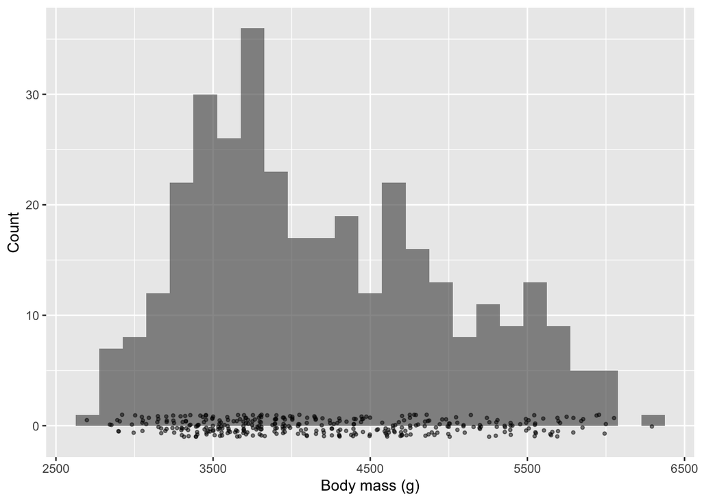

```r
ggplot(penguins, aes(x = body_mass_g)) +
  # histogram is first layer
  geom_histogram(bins=25, alpha=0.65) +
  # jitter points are second layer
  geom_jitter(aes(y = 0),
              height = 1,
              size=0.85,
              alpha=0.5) +
  labs(x = "Body mass (g)", y = "Count") +
  guides(fill = "none")
```

## Part a

**Modify the code above** to produce a plot like the following:

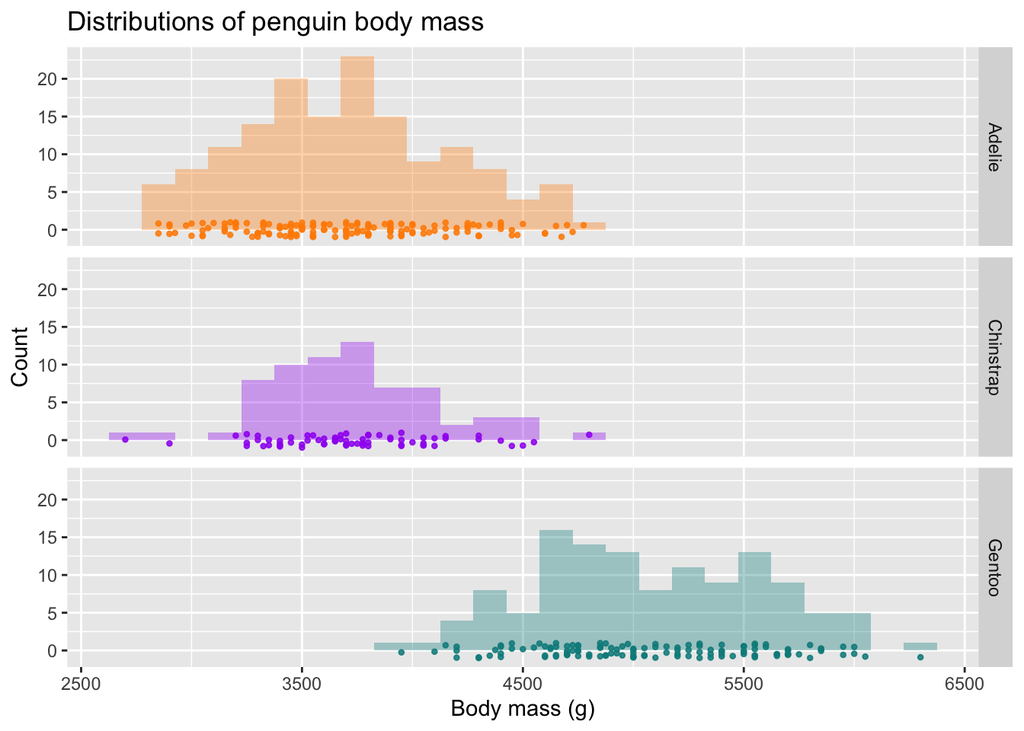

## Part b

A violin plot (`geom_violin`) allows a similar comparison to the above faceted histogram, without the need to facet.

**Modify the code below** using to produce the plot that follows.

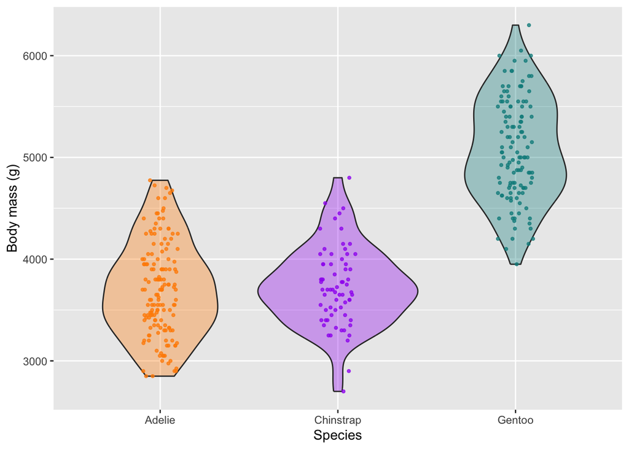

```r
ggplot(penguins, aes(x = species, y = body_mass_g)) +
  geom_violin(alpha=0.35) +
  labs(x = "Species", y = "Body mass (g)") +
  guides(fill = "none", color = "none")
```

### Part c

Many animals exhibit sexual dimorphism. Filter out any samples with missing sex information and extend your violin plot from the previous example to generate the a plot showing the distribution of body mass for each species faceted by sex. Is there evidence of dimorphism in body mass?

## Problem 06

The following biplot shows the relationship between bill length and depth.

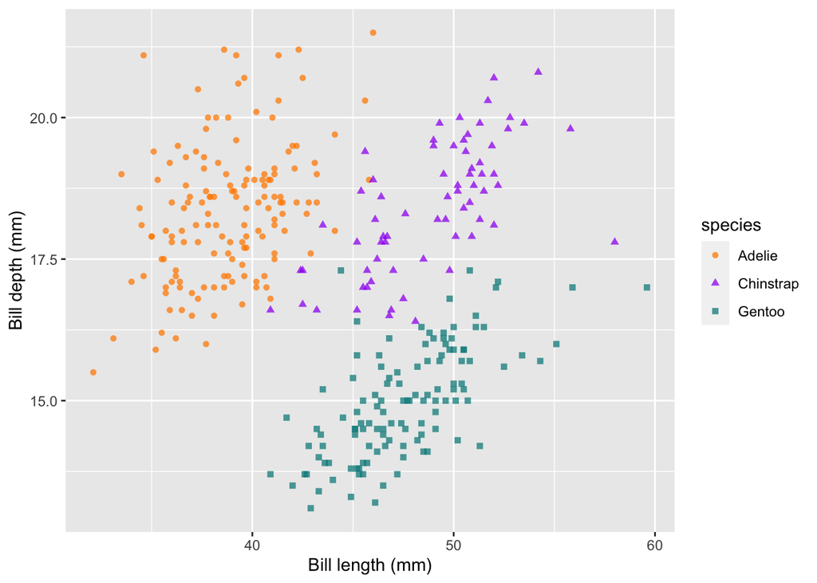

```r
penguins |>
  filter(!is.na(sex)) |>
  ggplot(aes(x = bill_length_mm,
             y = bill_depth_mm,
             shape = species,
             color = species)) +
  geom_point(alpha=0.75) +
  scale_color_manual(values = penguin_colors) +
  labs(x = "Bill length (mm)",
       y = "Bill depth (mm)")
```

### Part a

Find pictures of Adelie, Chinstrap, and Gentoo penguins with their beaks in profile on the web and embed images in your notebook like the one shown here.

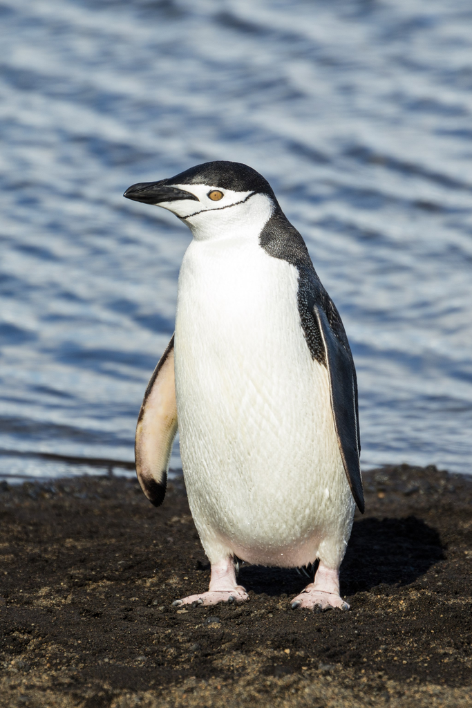

An image of a Chinstrap penguin from penguinsblog.com

[figure not shown]

[figure not shown]

Figure 1: Penguins!

### Part b

Based on your intense study of penguin beaks, and the figure above, formulate a hypothesis about the shapes of beaks in these three penguin species. Generate one or more data visualizations below to explore this hypothesis based on the Palmer Penguins data set.